# Sobre

29/01/2020

**Nome: William Barbosa**

**Nacionalidade:** Brasileiro

**Nascimento:** 15/04/1989

**Naturalidade:** Ponta Grossa - PR

**Residência:** Piracicaba - SP

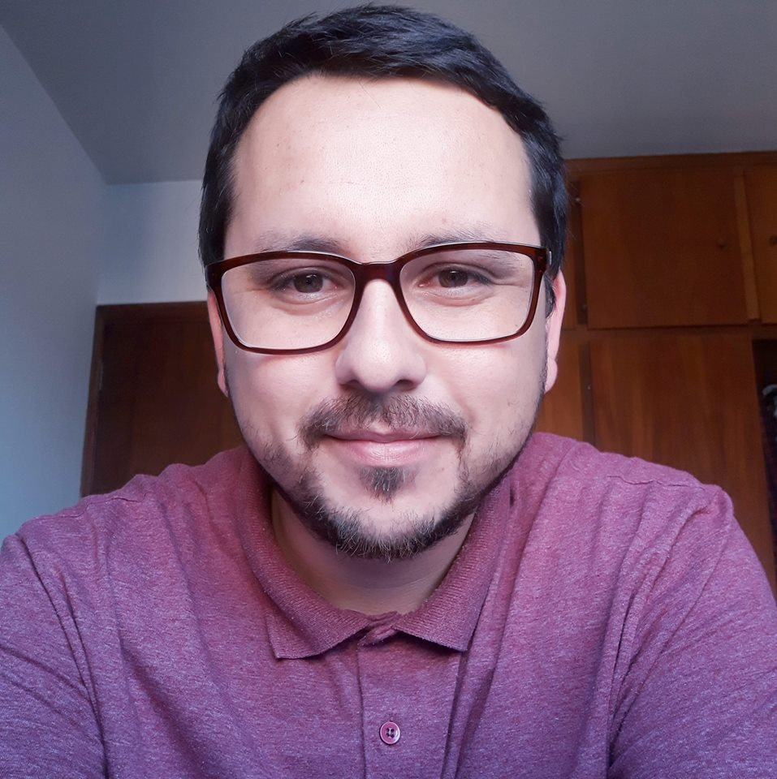

_________________________________________________________________________________________________________________

**Endereço profissional**

Universidade de São Paulo, Escola Superior de Agricultura Luiz de Queiroz, Departamento de Economia Administração e Sociologia. Av. Pádua Dias, 11, Agronomia, CEP: 13418900 - Piracicaba, SP - Brasil

**Telefone:** (19) 34294444

Fax: (19) 34345186

E-mail: williambarbosa@usp.br / william.economist@gmail.com

_________________________________________________________________________________________________________________

**Formação Acadêmica/Titulação**

**2017 - Atual** Doutorado em Ciências (Economia Aplicada).

Universidade de São Paulo, USP, São Paulo, Brasil

Título: **CENÁRIOS DE MUDANÇAS CLIMÁTICAS NA AGRICULTURA E MIGRAÇÕES INTERNAS NO BRASIL: UMA APLICAÇÃO DO MODELO DE EQUILÍBRIO GERAL COMPUTÁVEL**

Orientador: Joaquim Bento de Souza Ferreira Filho

Bolsista do(a): Coordenação de Aperfeiçoamento de Pessoal de Nível Superior

**2015 - 2017** Mestrado Em Economia e Desenvolvimento.

Universidade Federal de Santa Maria, UFSM, Santa Maria, Brasil

Título: **MIGRAÇÕES NO BRASIL: UMA APLICAÇÃO DO MODELO GRAVITACIONAL COM DADOS EM PAINEL (2002-2015)**, Ano de obtenção: 2017

Orientador: Clailton Ataídes de Freitas

Bolsista do(a): Coordenação de Aperfeiçoamento de Pessoal de Nível Superior

**2019** Especialização em MBA em Agronegócios.

Instituto de Pesquisas e Educação Continuada Economia e Gestão de Empresas, I-PECEGE, Piracicaba, Brasil

**2011 - 2014** Graduação em Ciências Econômicas.

Universidade Estadual de Ponta Grossa, UEPG, Ponta Grossa, Brasil

Título: **Análise Empírica da Evidência da Desindustrialização no Estado do Paraná no Período de 1996 a 2012**

Orientador: Alex Sander Souza do Carmo

_________________________________________________________________________________________________________________

**Área de conhecimento**

- Programação avançada para análise de dados em R, Stata e iniciante em Python;
- Especialidade em análise, manipulação, limpeza de dados e base de dados com R;
- Manipulação e tratamento de séries temporais com R; dados espaciais com R, QGIS e Geoda;
- Banco de dados; MySQL; RSQL; SQLDF;
- Métodos quantitativos;
- Modelagem com econometria de séries temporais;
- Modelagem com econometria de dados espaciais;
- Modelagem com dados do tipo *cross-section* e em painel;
- Modelagem com *Probit*, *Tobit* e *Logit*;
- Geração de relatórios automatizados com LaTeX, Markdown e R-Sweave;
- Pacote Office, especialmente Excel Avançado, Word e PowerPoint;
- Manipulações e extração de informações de microdados da PNAD, CENSO, RAIS, etc.;
- Estudos de viabilidade econômica.

_________________________________________________________________________________________________________________

**Interesses acadêmicos**

- Modelo de equilíbrio geral computável;
- Modelagem com dados em painel e séries temporais;
- Modeos de dados espaciais, cross section e painel;
- Modelagem de previsão de risco e retorno;
- Análise e modelos de previsão;
- Estudos quantitativos sobre aspectos econômicos, sociais e migrações internas/internacionais;
- Pesquisa relacionada ao uso da terra, agricultura, mudanças climáticas e migrações;
- Modelo gravitacional e comércio internacional;
- Estudos sobre a indústria brasileira e seu aspecto espacial, política industrial e *doença holandesa*;
- Complexidade Econômica.

_________________________________________________________________________________________________________________

**Vínculo institucional**

**2019 - Atual** Vínculo: Colaborador. Enquadramento funcional: Professor orientador na área de gestão de negócios e projetos. Regime: Integral

**2019 - Atual** Vínculo: Consultor externo. Enquadramento funcional: Consultor/Parecerista de estudos de viabilidade econômica e fluxos de caixa na área de gestão de negócios. Regime: Integral

_________________________________________________________________________________________________________________

**Revisor de periódico:**

**1. ECONOMIA & REGIÃO**

**2017 - Atual**

_________________________________________________________________________________________________________________

**Artigos completos publicados em periódicos**

1. OLIVEIRA, E. A.; FEISTEL, P. R.; **BARBOSA, W.** O Pecado Original Doméstico: Uma Análise Da Experiência Brasileira Entre 2001 A 2016. ESTUDO & DEBATE (ONLINE)., v.26, p.7 - 33, 2019.
2. OLIVEIRA, E. A.; **BARBOSA, W.** ; CATEIA, J. V.; FEISTEL, P. R. AS EXPORTAÇÕES BRASILEIRAS POR GRAU DE ELABORAÇÃO ENTRE 1980 E 2015: APLICAÇÃO DO MODELO EATON-KORTUM À LUZ DA TEORIA CEPALINA. Análise Econômica (UFRGS) on-line. , v.36, p.179 - 201, 2018.
3. SILVA, J. V. S.; **BARBOSA, W.** ; FREITAS, C. A. Complementaridade Comercial entre Brasil e América do Sul: Aplicação do modelo gravitacional em dados em painel para o mercado de bens de alta intensidade tecnológica. RBEE. REVISTA BRASILEIRA DE ECONOMIA DE EMPRESAS. , v.18, p.43 - 63, 2018.
4. SILVA, J. V. S.; **BARBOSA, W.** A América do Sul no Dinamismo Comercial Brasileiro: Um Estudo Das Complementaridades Por Intensidade Tecnológica. OBSERVATORIO DE LA ECONOMÍA LATINOAMERICANA. , v.3, p.1-17 - , 2017.
5. **BARBOSA, W.** ; OLIVEIRA, E. A.; FREITAS, C. A.; SILVA, J. V. S. UMA ANÁLISE DA CURVA DE KUZNETS PARA OS MUNICÍPIOS BRASILEIROS (1991, 2000, 2010). ECONOMIA & REGIÃO. , v.5, p.65 - 83, 2017.
6. OLIVEIRA, E. A.; **BARBOSA, W.** ; ROHENKOHL, J. E. CRISE SUBPRIME: UMA EXPLICAÇÃO COM BASE NO CONCEITO DE DIREITOS DE PROPRIEDADE. Revista da FAE. , v.19, p.52 - 74, 2016.
7. **BARBOSA, W.** ; OLIVEIRA, E. A.; FREITAS, C. A.; FEISTEL, P. R. MIGRAÇÕES INTERESTADUAIS: UMA APLICAÇÃO DO MODELO GRAVITACIONAL PARA OS ESTADOS BRASILEIROS. Revista Brasileira de Estudos Regionais e Urbanos. , v.10, p.156 - 176, 2016.
8. OLIVEIRA, E. A.; **BARBOSA, W.** ; FREITAS, C. A. Ordem e caos: um conceito alternativo de mercado. Estudos do CEPE. , p.04 - , 2016.
9. **BARBOSA, W.** ; PELINSKI, A. R.; CARMO, A. S. S. Existe desindustrialização no Estado do Paraná? um teste empírico para o período de 1996 a 2012. INFORME GEPEC (ONLINE). , v.19, p.55 - 79, 2015.

**Trabalhos publicados em anais de eventos (completo)**

1. **BARBOSA, W.** ; FREITAS, C. A.; OLIVEIRA, E. A. DESIGUALDADE DE RENDA, CAPITAL HUMANO E POPULAÇÃO RURAL-URBANA: UMA ANÁLISE DA CURVA DE KUZNETS PARA O MUNICÍPIOS BRASILEIROS (1991, 2000 E 2010) In: 54º Congresso da Sociedade Brasileira de Economia, Administração e Sociologia Rural, 2016, Maceió - AL. **Desenvolvimento, território e biodiversidade**. , 2016.
2. OLIVEIRA, E. A.; **BARBOSA, W.** ; FREITAS, C. A.; CASAGRANDE, D. Estagnação da produtividade do fator trabalho no Brasil entre 1950 a 2008: uma decomposição dos fatores de curto e longo prazo. In: XXI Encontro Regional de Economia/XXII Fórum Banco do Nordeste de Desenvolvimento, 2016, Fortaleza. **XXII Fórum Banco do Nordeste de Desenvolvimento**. , 2016.